[figure not shown]

# Determinants of GDP per Capita Growth in the EU

## A Panel Data Analysis (2014–2023)

Mehmet Karaca | Alexander XY | Ammar | Khuzaima

NOVA Information Management School (NOVA IMS), Lisbon

[figure not shown]

### Introduction

27 EU Countries

10 Years

~270 Observations

- **Context:** Migration crisis (2015), COVID-19 (2020), recovery (2021–22)
- **Goal:** Identify key drivers of economic growth across EU
- **Approach:** Panel econometrics with country fixed effects

### Research Question

**How do migration, unemployment, and investment affect GDP per capita growth in the EU?**

### Hypotheses

- **H1:** Migration ↑ → GDP Growth ↑ *(Labor supply)*
- **H2:** Unemployment ↑ → GDP Growth ↓ *(Demand loss)*
- **H3:** Investment ↑ → GDP Growth ↑ *(Capital accumulation)*

### Data

**Source:** Eurostat (2014–2023)

| Variable | Description | Unit |
| --- | --- | --- |
| **GDP Growth** | Real GDP per capita growth | % |
| **Migration** | Net migration rate | ‰ |
| **Unemployment** | Rate (15–74 years) | % |
| **Investment** | Gross fixed capital formation | % GDP |

### Methodology

**Panel Models Compared:**

| Model | Purpose |
| --- | --- |
| Pooled OLS | Baseline |
| **Fixed Effects** | Controls unobserved heterogeneity |
| Random Effects | Efficiency under exogeneity |

**Model Selection:** - Hausman Test → **FE preferred** - F-Test → Individual effects significant - Robust SE (cluster) for inference

### Diagnostics

| Test | Result | Action |
| --- | --- | --- |
| Hausman | p < 0.05 | → Use FE |
| F-Test | p < 0.001 | → Effects present |
| BP (Hetero.) | p < 0.05 | → Robust SE |

**→ FE model with cluster-robust SE**

### Results

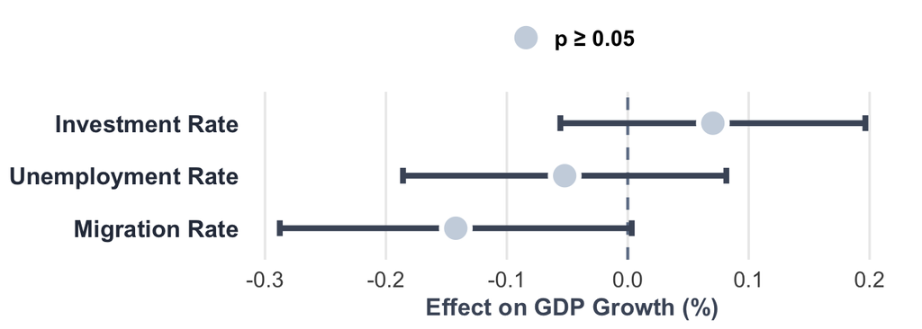

| Variable | Coef | SE | Sig |
| --- | --- | --- | --- |
| Migration Rate | -0.142 | 0.074 |  |
| Unemployment Rate | -0.052 | 0.068 |  |
| Investment Rate | 0.070 | 0.064 |  |

### References

Eurostat (2024) · Boubtane et al. (2016) · Ortega & Peri (2013) · Wooldridge (2010)